# Semana 7 - Ciencia de Datos con Python

[figure not shown]

```r
knitr::opts_chunk$set(echo = TRUE)
library(reticulate)
# use_python("/Users/oldemarrodriguez/anaconda3/bin/python3.7") # PROMIDAT
use_python("/anaconda3/bin/python3.6") ## Portátil
```

# Métodos de Potenciación

```python
import os
import pandas as pd
import numpy as np
import matplotlib.pyplot as plt
from sklearn.model_selection import train_test_split
from sklearn.ensemble import AdaBoostClassifier
from sklearn.ensemble import GradientBoostingClassifier
from sklearn.metrics import confusion_matrix
```

**Para mostrar un gráfico en un archivo rmd use show() y close()**

```python
def open_close_plot():
    plt.show()
    plt.close()
```

**Índices para matrices NxN**

```python
def indices_general(MC, nombres = None):
    precision_global = np.sum(MC.diagonal()) / np.sum(MC)
    error_global = 1 - precision_global
    presicion_categoria  = pd.DataFrame(MC.diagonal()/np.sum(MC,axis = 1)).T
    if nombres!=None:
        presicion_categoria.columns = nombres
    return {"Matriz de Confusión":MC,
            "Precisión Global":precision_global,
            "Error Global":error_global,
            "Precisión por Categoría":presicion_categoria}
```

# Potenciación con ADA Boosting

# Ejemplo datos de Iris

```python
os.chdir("/Users/oldemarrodriguez/Google Drive/MDCurso/Datos")
print(os.getcwd())
```

```
## /Users/oldemarrodriguez/Google Drive/MDCurso/Datos
```

```python
datos = pd.read_csv('iris.csv',delimiter=';',decimal=".")
print(datos.shape)
```

```
## (150, 5)
```

```python
print(datos.head())
```

```
##    s.largo  s.ancho  p.largo  p.ancho    tipo
## 0      5.1      3.5      1.4      0.2  setosa
## 1      4.9      3.0      1.4      0.2  setosa
## 2      4.7      3.2      1.3      0.2  setosa
## 3      4.6      3.1      1.5      0.2  setosa
## 4      5.0      3.6      1.4      0.2  setosa
```

```python
print(datos.info())
```

```
## <class 'pandas.core.frame.DataFrame'>
## RangeIndex: 150 entries, 0 to 149
## Data columns (total 5 columns):
## s.largo    150 non-null float64
## s.ancho    150 non-null float64
## p.largo    150 non-null float64
## p.ancho    150 non-null float64
## tipo       150 non-null object
## dtypes: float64(4), object(1)
## memory usage: 5.9+ KB
## None
```

**Elimina la variable catégorica, deja las variables predictoras en X**

```python
X = datos.iloc[:,:4]
print(X.head())
```

```
##    s.largo  s.ancho  p.largo  p.ancho
## 0      5.1      3.5      1.4      0.2
## 1      4.9      3.0      1.4      0.2
## 2      4.7      3.2      1.3      0.2
## 3      4.6      3.1      1.5      0.2
## 4      5.0      3.6      1.4      0.2
```

**Deja la variable a predecir en y**

```python
y = datos.iloc[:,4:5]
print(y.head())
```

```
##      tipo
## 0  setosa
## 1  setosa
## 2  setosa
## 3  setosa
## 4  setosa
```

**Con el 70% de los datos para entrenamiento**

```python
X_train, X_test, y_train, y_test = train_test_split(X, y, train_size=0.7, random_state=0)
print(X_train)
```

```
##      s.largo  s.ancho  p.largo  p.ancho
## 60       5.0      2.0      3.5      1.0
## 116      6.5      3.0      5.5      1.8
## 144      6.7      3.3      5.7      2.5
## 119      6.0      2.2      5.0      1.5
## 108      6.7      2.5      5.8      1.8
## 69       5.6      2.5      3.9      1.1
## 135      7.7      3.0      6.1      2.3
## 56       6.3      3.3      4.7      1.6
## 80       5.5      2.4      3.8      1.1
## 123      6.3      2.7      4.9      1.8
## 133      6.3      2.8      5.1      1.5
## 106      4.9      2.5      4.5      1.7
## 146      6.3      2.5      5.0      1.9
## 50       7.0      3.2      4.7      1.4
```

[output cut: 49 more lines]

```python
print(X_test)
```

```
##      s.largo  s.ancho  p.largo  p.ancho
## 114      5.8      2.8      5.1      2.4
## 62       6.0      2.2      4.0      1.0
## 33       5.5      4.2      1.4      0.2
## 107      7.3      2.9      6.3      1.8
## 7        5.0      3.4      1.5      0.2
## 100      6.3      3.3      6.0      2.5
## 40       5.0      3.5      1.3      0.3
## 86       6.7      3.1      4.7      1.5
## 76       6.8      2.8      4.8      1.4
## 71       6.1      2.8      4.0      1.3
## 134      6.1      2.6      5.6      1.4
## 51       6.4      3.2      4.5      1.5
## 73       6.1      2.8      4.7      1.2
## 54       6.5      2.8      4.6      1.5
```

[output cut: 31 more lines]

```python
print(y_train)
```

```
##            tipo
## 60   versicolor
## 116   virginica
## 144   virginica
## 119   virginica
## 108   virginica
## 69   versicolor
## 135   virginica
## 56   versicolor
## 80   versicolor
## 123   virginica
## 133   virginica
## 106   virginica
## 146   virginica
## 50   versicolor
```

[output cut: 49 more lines]

```python
print(y_test)
```

```
##            tipo
## 114   virginica
## 62   versicolor
## 33       setosa
## 107   virginica
## 7        setosa
## 100   virginica
## 40       setosa
## 86   versicolor
## 76   versicolor
## 71   versicolor
## 134   virginica
## 51   versicolor
## 73   versicolor
## 54   versicolor
```

[output cut: 31 more lines]

**Mediante el constructor inicializa la instancia_potenciacion** **n_estimators es el número de árboles que usará**

```python
instancia_potenciacion = AdaBoostClassifier(n_estimators=10, random_state=0)
```

**Entrena el modelo llamando al método fit**

```python
instancia_potenciacion.fit(X_train,y_train)
```

**Imprime las predicciones en testing**

```python
print("Las predicciones en Testing son: {}".format(instancia_potenciacion.predict(X_test)))
```

```
## Las predicciones en Testing son: ['virginica' 'versicolor' 'setosa' 'virginica' 'setosa' 'virginica'
##  'setosa' 'versicolor' 'versicolor' 'versicolor' 'virginica' 'versicolor'
##  'versicolor' 'versicolor' 'versicolor' 'setosa' 'versicolor' 'versicolor'
##  'setosa' 'setosa' 'versicolor' 'versicolor' 'setosa' 'setosa'
##  'versicolor' 'setosa' 'setosa' 'versicolor' 'versicolor' 'setosa'
##  'virginica' 'versicolor' 'setosa' 'versicolor' 'virginica' 'versicolor'
##  'setosa' 'virginica' 'versicolor' 'versicolor' 'virginica' 'setosa'
##  'virginica' 'setosa' 'setosa']
```

**Porcentaje de predicción global**

```python
print("Precisión en Testing: {:.3f}".format(instancia_potenciacion.score(X_test, y_test)))
```

```
## Precisión en Testing: 0.911
```

**Matriz de confusión**

```python
prediccion = instancia_potenciacion.predict(X_test)
MC = confusion_matrix(y_test, prediccion)
print("Matriz de Confusión:\n{}".format(MC))
```

```
## Matriz de Confusión:
## [[16  0  0]
##  [ 0 17  1]
##  [ 0  3  8]]
```

## Índices de Calidad del Modelo

```python
indices = indices_general(MC,list(np.unique(y)))
```

```python
for k in indices:
    print("\n%s:\n%s"%(k,str(indices[k])))
```

```
##
## Matriz de Confusión:
## [[16  0  0]
##  [ 0 17  1]
##  [ 0  3  8]]
##
## Precisión Global:
## 0.9111111111111111
##
## Error Global:
## 0.0888888888888889
##
## Precisión por Categoría:
##    setosa  versicolor  virginica
## 0     1.0    0.944444   0.727273
```

**Importancia de la variables**

```python
importancia = instancia_potenciacion.feature_importances_
print(importancia)
```

```
## [0.  0.  0.3 0.7]
```

## Graficando la importancia

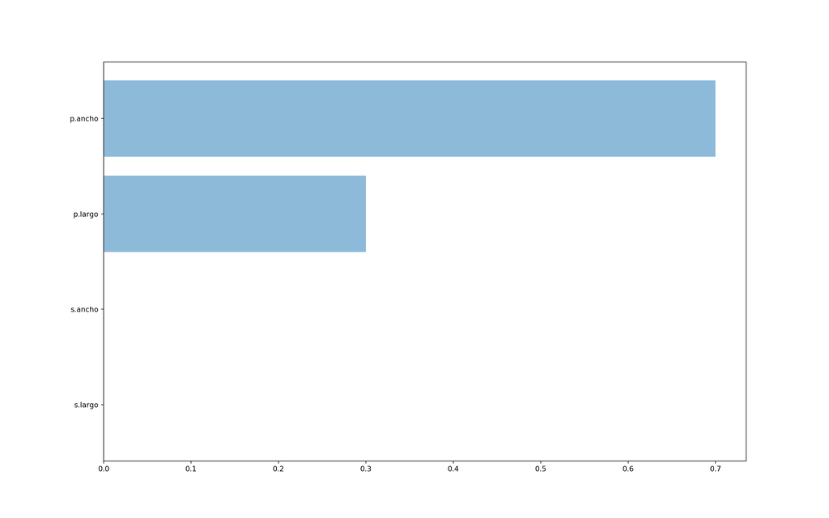

```python
etiquetas = X_train.columns.values
y_pos = np.arange(len(etiquetas))
plt.barh(y_pos, importancia, align='center', alpha=0.5)
plt.yticks(y_pos, etiquetas)
open_close_plot()
```

**Elimina la variable categórica, deja como variables predictoras en X solamente a p.largo y p.ancho**

```python
X = datos.iloc[:,2:4]
print(X.head())
```

```
##    p.largo  p.ancho
## 0      1.4      0.2
## 1      1.4      0.2
## 2      1.3      0.2
## 3      1.5      0.2
## 4      1.4      0.2
```

**Deja la variable a predecir en y**

```python
y = datos.iloc[:,4:5]
print(y.head())
```

```
##      tipo
## 0  setosa
## 1  setosa
## 2  setosa
## 3  setosa
## 4  setosa
```

**Mediante el constructor inicializa la instancia_potenciacion**

```python
instancia_potenciacion = GradientBoostingClassifier(n_estimators=10, random_state=0)
```

**Entrena el modelo llamando al método fit**

**Nota:**Esto se debe a que al ser Python orientado a Objetos,el modelo queda en un atributo de la instancia “instancia_potenciacion” llama el método fit de cla clase GradientBoostingClassifier.

```python
instancia_potenciacion.fit(X_train,y_train)
```

**Imprime las predicciones en testing**

```python
print("Las predicciones en Testing son: {}".format(instancia_potenciacion.predict(X_test)))
```

```
## Las predicciones en Testing son: ['virginica' 'versicolor' 'setosa' 'virginica' 'setosa' 'virginica'
##  'setosa' 'versicolor' 'versicolor' 'versicolor' 'virginica' 'versicolor'
##  'versicolor' 'versicolor' 'versicolor' 'setosa' 'versicolor' 'versicolor'
##  'setosa' 'setosa' 'virginica' 'versicolor' 'setosa' 'setosa' 'virginica'
##  'setosa' 'setosa' 'versicolor' 'versicolor' 'setosa' 'virginica'
##  'versicolor' 'setosa' 'virginica' 'virginica' 'versicolor' 'setosa'
##  'virginica' 'versicolor' 'versicolor' 'virginica' 'setosa' 'virginica'
##  'setosa' 'setosa']
```

**Porcentaje de predicción global**

```python
print("Precisión en Testing: {:.3f}".format(instancia_potenciacion.score(X_test, y_test)))
```

```
## Precisión en Testing: 0.978
```

**Matriz de confusión**

```python
prediccion = instancia_potenciacion.predict(X_test)
MC = confusion_matrix(y_test, prediccion)
print("Matriz de Confusión:\n{}".format(MC))
```

```
## Matriz de Confusión:
## [[16  0  0]
##  [ 0 17  1]
##  [ 0  0 11]]
```

## Índices de Calidad del Modelo

```python
indices = indices_general(MC,list(np.unique(y)))
```

```python
for k in indices:
    print("\n%s:\n%s"%(k,str(indices[k])))
```

```
##
## Matriz de Confusión:
## [[16  0  0]
##  [ 0 17  1]
##  [ 0  0 11]]
##
## Precisión Global:
## 0.9777777777777777
##
## Error Global:
## 0.022222222222222254
##
## Precisión por Categoría:
##    setosa  versicolor  virginica
## 0     1.0    0.944444        1.0
```